# The Double Burden: Child Deprivation and Vaccine Coverage

A UNICEF Data Analysis Report

Author

Girish Rajendra Ghate

Published

April 15, 2026

Every child deserves a healthy start to life, yet millions around the world face **multiple overlapping disadvantages** — from lack of clean water and sanitation to inadequate nutrition and healthcare access.

This report examines two critical dimensions of child wellbeing using *UNICEF* data:

1. **Child deprivation** — the percentage of children suffering from exactly five simultaneous deprivations
2. **Vaccine coverage** — the percentage of infants receiving their first dose of inactivated polio vaccine (IPV1)

By combining these indicators with economic metadata such as GDP per capita and life expectancy, we uncover a troubling pattern: **13 countries** face a “double burden” where children experience both high deprivation *and* low vaccine coverage — including *Madagascar*, *Ethiopia*, *Chad*, and *Nigeria*.

## 1 Exploratory Data Analysis

Before creating visualisations, I explored all three datasets to understand their structure, coverage, and data quality.

### 1.1 Key EDA Findings

- **Child deprivation data** covers **72 countries** across **2011–2018** with Male, Female, and Total breakdowns. Most values cluster near zero, with **Madagascar (1.43%)** and **Ethiopia (1.22%)** showing the highest deprivation rates. There are **0 missing values**.
- **Vaccine coverage data** covers **194 countries** across **2015–2024**. Coverage ranges from **0% to 99%**, with significant regional variation.
- **Economic metadata** spans **1960–2024** across **211 countries**, but contains **2,494 missing values** for GDP per capita and **245 missing values** for life expectancy.
- The indicator datasets use different year formats from the metadata, which required alignment before joining.
- **72 countries** appear in both indicator files, enabling cross-analysis of deprivation and vaccine coverage.

## 2 Data Preparation and Transformations

I used **left joins** to preserve all indicator observations, even for countries where economic data was unavailable. Year formats were aligned across datasets to ensure accurate matching.

## 3 Global Vaccine Coverage: A World Map

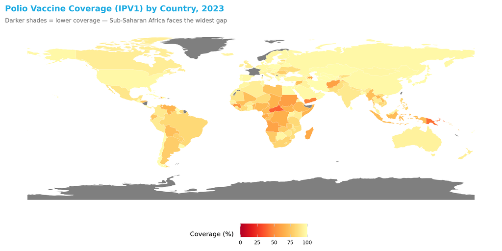

Figure 1: Global Polio Vaccine Coverage (IPV1), 2023

The map confirms a clear **north-south divide**. Countries like **Central African Republic (39%)**, **Papua New Guinea (42%)**, and **Yemen (48%)** have coverage below 50%, while Europe achieves near-universal coverage.

## 4 Regional Comparison: Vaccine Coverage by Continent

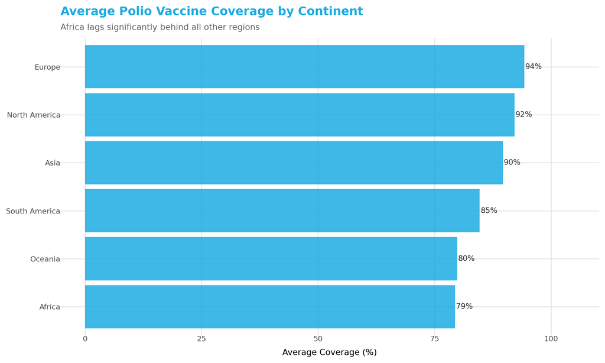

Figure 2: Average Polio Vaccine Coverage by Continent, 2023

**Africa** has the lowest average coverage, falling well below the global 90% target. **Europe** leads with near-universal coverage. This gap mirrors broader patterns of healthcare investment.

## 5 The Economic Link: GDP and Vaccine Coverage

Is vaccine coverage simply a matter of national wealth? The scatterplot below examines this relationship with a linear regression line.

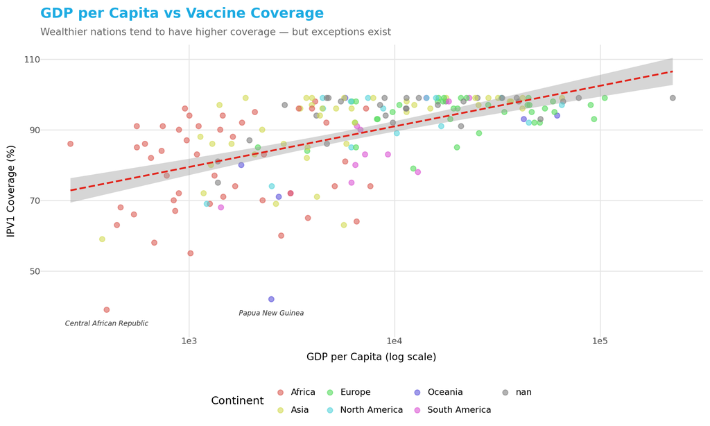

Figure 3: GDP per Capita vs Vaccine Coverage

The regression line shows a **positive correlation** — wealthier nations tend to have higher coverage. However, several low-income countries achieve coverage above 80%, proving that **policy choices and healthcare systems** matter as much as raw wealth.

## 6 Trends Over Time: Double-Burden Countries

How has vaccine coverage evolved in nations facing the double burden of high child deprivation *and* low vaccine coverage?

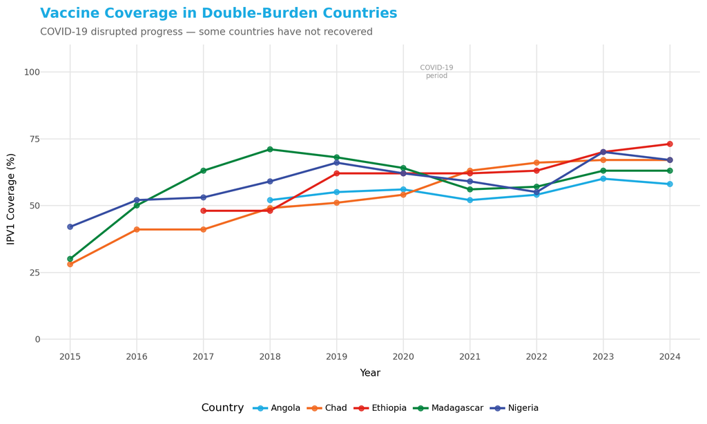

Figure 4: Vaccine Coverage Trends in Double-Burden Countries (2015–2024)

## 7 Gender Disparity in Child Deprivation

Does deprivation affect boys and girls equally? Using the gender- disaggregated data in Indicator 1, I compare male and female rates across the most affected countries.

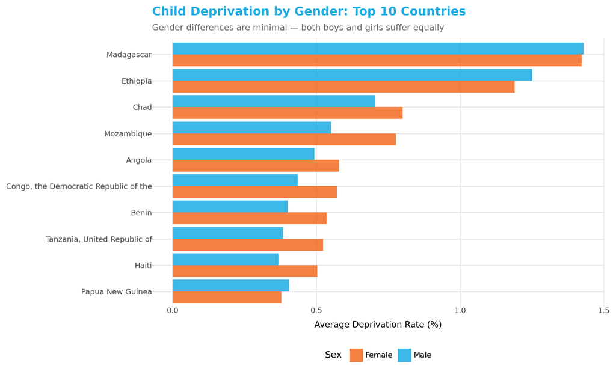

Figure 5: Child Deprivation by Gender: Top 10 Countries

## 8 Conclusion

These findings underscore the urgent need for **targeted investment** in the 13 double-burden countries, where children face overlapping vulnerabilities demanding an integrated response.